# Introducción al modelado estadístico

S Mandujano R

2020-06-28 14:30:03

# Basado en:

**Korner-Nievergelt et al. 2015. *Análisis de datos Bayesian en ecología*, Springer, UK. 316 pp.**

# ¿Por qué necesitamos modelos estadísticos?

**Los modelos estadísticos ayudan a entender los sistemas naturales**.

- Un **modelo estadístico** es una construcción matemática basada en la teoría de la probabilidad que tiene como objetivo reconstruir el sistema o el proceso en estudio.
- Entonces, los **datos** que obtenemos en campo y/o en laboratorio, son observaciones de este sistema o proceso.
- Los modelos expresan lo que sabemos o creemos saber sobre un sistema natural.
- Un aspecto importante es que la diferencia entre el modelo y las observaciones muestra que lo que pensamos sobre el sistema puede no ser realista y, por lo tanto, señala en qué podemos pensar más intensamente.
- Esta diferencia se mide o expresa a través de los llamadados **residuales**.

# Por cierto

- Rara vez se aplica un solo modelo a los datos y se extraen conclusiones de los resultados.
- Por el contario, es un proceso iterativo de ajustar varios modelos, comparar el modelo con los datos, obtener información sobre el sistema a partir de discrepancias específicas entre los modelos y los datos, y luego encontrar el modelo más realista.
- Es decir, analizar datos usando modelos estadísticos es un proceso de aprendizaje.

# Además

- Frecuentemen varios modelos pueden ser plausibles y ajustarse a los datos razonablemente bien.
- En tales casos, la inferencia puede basarse en el conjunto de todos los modelos, o se selecciona un modelo que funcione mejor para un propósito específico.
- Una vez que se tiene uno o varios modelos se hacen inferencias.
- Por ejemplo, se extraen las estimaciones de los efectos de las variables predictoras en las variables dependientes junto con una estimación de incertidumbre.

*En este sentido, el presente curso trata sobre una amplia clase de modelos estadísticos llamados modelos lineales aplicados a las relaciones de la fauna-hábitat*.

# Estructura general de un modelo

- Los modelos estadísticos tienen una parte *sistemática* y una parte *estocástica*.
- La parte sistemática describe cómo la variable de resultado (*y*, variable de interés) se relaciona con las variables predictoras (*x*, variables explicativas).
- Una línea de regresión es la parte sistemática del modelo, y la dispersión de los datos alrededor de la línea de regresión (más precisamente: *la distribución de los residuos*) es la parte estocástica.
- Los modelos lineales (LM por sus siglas en inglés) son probablemente los modelos más utilizados en ecología y en muchas otras áreas de investigación.

# Piezas de “Lego”" importantes en este curso

- modelos lineales (LM)
- modelos lineales generalizados (GLM)
- modelos lineales con efectos mixtos simples (LMM) y generalizados (GLMM)
- modelos jerárquicos, secuenciales o de estado (HM, **hierarchical models**)

# Por si no lo sabías

La gran mayoría de las pruebas estadísticas clásicas que uno emplea son: MODELOS LINEALES, por ejemplo:

- t-Student
- regresión/correlación lineal simple/múltiple
- regresión logística
- análisis de covarianza (ANCOVA)
- ANOVA de 1 o 2 vías
- prueba Chi-cuadrada
- análisis de componentes principales
- análisis de correspondencia
- análisis de agrupamientos
- entre muchas…!

# Aspecto esencial de los LM

Los modelos lineales se basan en el supuesto o hipótesis de que los datos tiene o provienen de una **distribución normal**, las varianzas homogéneas, y otros.

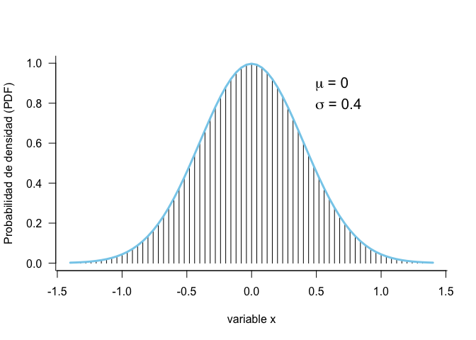

```r
# EJEMPLO DISTRIBUCIÓN NORMAL

par(mfrow= c(1,1))

# ejemplo 1
media <- 0.0
sd <- 0.4
x_menor <- media - 3.5*sd
x_mayor <- media + 3.5*sd
dx <- sd/10 # intervalos o ancho de cada barra bajo la curva

# secuencia de valores en el eje-X
x <- seq(from= x_menor, to= x_mayor, by= dx)

# calcula la probabididad de densidad para cada valor de X
y <- (1/(sd*sqrt(2*pi))) * exp(-0.5*((x-media)/sd)^2)

plot(x,y, type="h", col= "black", lwd=1, cex.axis=1.0, xlab="variable x", bty="l", las=1, ylab="Probabilidad de densidad (PDF)" , cex.lab=1.0, main="", cex.main=1.0)
lines(x,y, lwd=3, col="skyblue")
text(media+0.75, 0.9*max(y), bquote(paste(mu," = ",.(media))), adj=c(1,0.5), cex=1.3)
text(media+0.85, 0.8*max(y), bquote(paste(sigma," = ",.(sd))), adj=c(1,0.5), cex=1.3)
```

# ¿Qué son los modelos lineales?

- En los modelos lineales el efecto de las covariables actuan sobre la variable de respuesta de una manera **aditiva**.
- Es decir, los LM se expresan como simples sumas ponderadas de los valores de las covariables.
- La ponderación o peso de las covariables son precisamente los coeficientes de los parámetros de los modelos lineales.
- Se pueden representar con la ecuación de la línea como:
  $$y = a \pm bx$$

donde: *y*= variable dependiente, *x*= variable independiente, *a*= ordenada al origen y *b*= pendiente.

# ejemplo

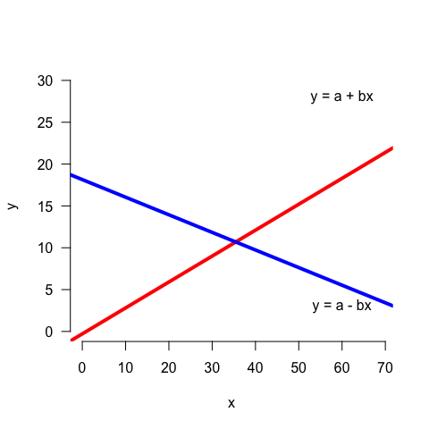

```r
cantos <- c(10,33,14,25,21,40,52,36,56,42,35,26,16,47,39,47,58,48,35,52)
ranas <- rpois(n = 20, lambda = cantos/3)
ranas2 <- sort(rpois(n = 20, lambda = cantos/3), decreasing = T)
plot(cantos, ranas, type = "n", pch = 16, cex = 1.5, frame.plot = F, col = "lightblue", xlim = c(0,69), ylim = c(0,30), las = 1, xlab="x", ylab = "y")
ajuste <- lm(ranas ~ cantos)
ajus2 <- lm(ranas2 ~ cantos)
abline(ajuste, col= "red", lwd= 4)
abline(ajus2, col= "blue", lwd= 4)
text(60,28,"y = a + bx")
text(60,3,"y = a - bx")
```

# Otras formas de representar los LM

$$y = \alpha + \beta x$$

$$y = \beta_0 + \beta_1 x$$

$$y = \beta_0 + \beta_1 x_1 + \beta_2 x_2...\beta_n x_3$$

$$y = \beta_0 + \beta_1 x_1 + \beta_2^2 x_2...\beta_n^3 x_3$$

# LM binomial

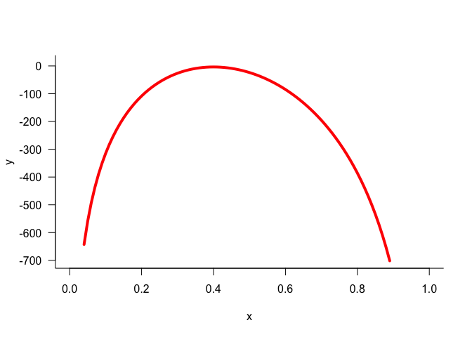

```r
N <- 1000
n <- 400
f <- function(N,n,p){log(dbinom(n,N,p))}
ps <- seq(0,1,0.01)
plot(ps, f(N,n,ps), type = "l", ylab = "y", xlab = "x", bty = "l", las = 1, ylim = c(-700,10), lwd = 4, col = "red")
```

# LM polinomial

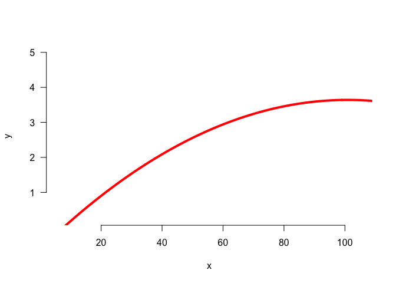

```r
datos <- read.csv("csv_txt/localidades.cvs", header = T)
attach(datos)
plot(GF, Density, frame.plot = F, las=1, xlab = "x", ylab = "y", type = "n")
mod3 <- lm(Density ~ GF + I(GF^2))
x <- 0:120
y <- predict(mod3, list(GF = x))
lines(x, y, col = "red", lwd = 4) # modelo Polinomial
```

```r
rm(x,y)
```

# Importante

Un modelo lineal no solo se representa como una línea recta sino que puede tomar diferentes formas…!

# Naturaleza de los modelos

$$observación = modelo + error$$

$$dato = promedio + varianza$$

$$y = \mu + \sigma^2$$

# Ejemplo: datos

| X | x | y |
| --- | --- | --- |
| 1 | 18.89537 | 19.133600 |
| 2 | 29.97081 | 18.482327 |
| 3 | 27.69788 | 18.869170 |
| 4 | 14.76852 | 11.141094 |
| 5 | 14.54628 | 18.022393 |
| 6 | 26.95539 | 16.878079 |
| 7 | 15.65123 | 19.010660 |
| 8 | 24.35217 | 12.939239 |
| 9 | 17.92102 | 14.527611 |
| 10 | 21.49319 | 20.686325 |
| 11 | 16.48755 | 11.034617 |
| 12 | 18.78839 | 16.049063 |
| 13 | 24.97537 | 19.783592 |
| 14 | 10.93625 | 10.253151 |
| 15 | 13.95873 | 11.651856 |
| 16 | 26.23524 | 16.913117 |
| 17 | 27.13940 | 18.025002 |
| 18 | 10.31151 | -2.478029 |
| 19 | 19.94047 | 6.987518 |
| 20 | 19.86405 | 15.287655 |

## gráfico de dispersión

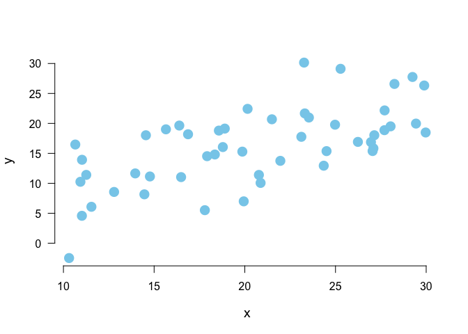

```r
attach(datos_LM)
plot(x, y, pch = 16, col = "skyblue", cex =2, las = 1, cex.lab = 1.2, bty= "l", frame.plot = F)
```

## ajuste de un modelo: cuadrados mínimos (OLs)

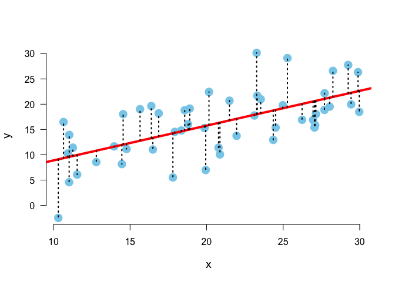

```r
plot(x, y, pch = 16, col = "skyblue", cex =2, las = 1, cex.lab = 1.2, bty= "l", frame.plot = F)
abline(lm(y ~ x), lwd = 4, col = "red")
segments(x, fitted(lm(y ~ x)), x, y, lwd = 2, col = "black", lty = 3)
```

## Modelo lineal

```r
(mod<-  lm(y ~ x))
```

```
##
## Call:
## lm(formula = y ~ x)
##
## Coefficients:
## (Intercept)            x
##       2.005        0.688
```

## resultados

|  | Estimate | Std. Error | t value | Pr(>\|t\|) |
| --- | --- | --- | --- | --- |
| (Intercept) | 2.0049517 | 2.5349385 | 0.7909272 | 0.4328772 |
| x | 0.6880415 | 0.1186375 | 5.7995259 | 0.0000005 |

# Práctica de regresión lineal simple